# college Data Science Project

## Decision Tree Structures

In here at first some **simple trees** are developed and we can use RF for feature selection. Then, I use **GBRegression** and **XGB** models.

### Model 3 Simple Decision Tree

#### Model 3-1 selected feature

we see the **Accept**, **Top 10** and **F.Undergraduate** are playing an important role, I choose these feature from **RF** and **LASSO**.

**Note:** Plot the tree, **CP** plays an important role and we have to measure it good. and find it the best one. So, we are going to prune it. I have brought some of those codes in the following:

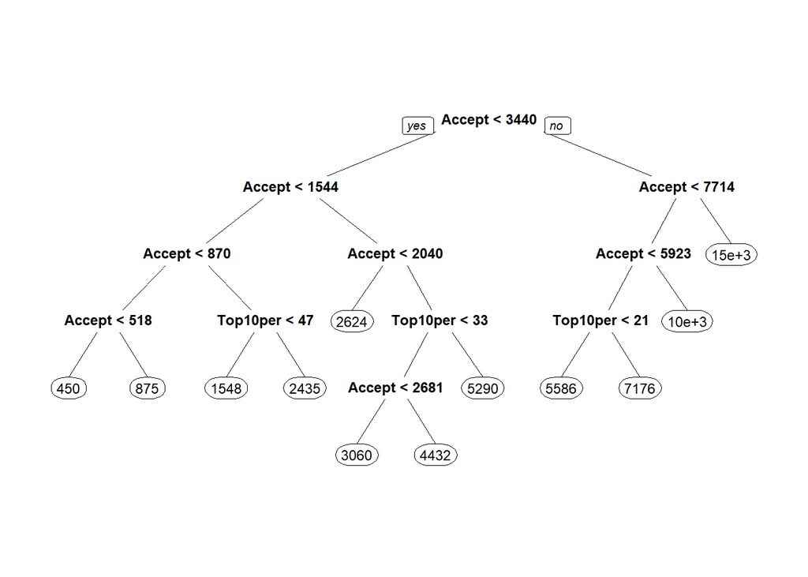

```r
tree_1 <- rpart(Apps ~ Private + Accept + Enroll + Top10perc + F.Undergrad
                + Outstate + Room.Board + Expend  + PhD, data = train2,
                control = list(cp = 0.01, maxdepth = 10, minbucket = 20))

tree_2 <- rpart(Apps ~ Private + Accept + Enroll + Top10perc + F.Undergrad
                + Outstate + Room.Board + Expend  + PhD, data = train2,
                control = list(cp = 0.001, maxdepth = 20, minbucket = 20))

tree_2P <- prune.rpart(tree_2,
                      cp = tree_2$cptable[which.min(tree_2$cptable[,"xerror"])])

prp(tree_2P)
```

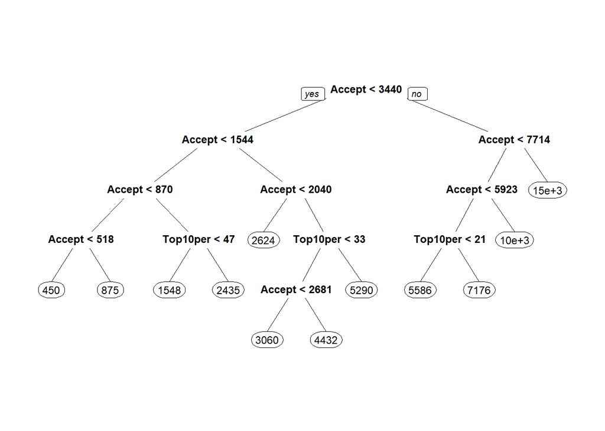

```r
tree_3 <- rpart(Apps ~ ., data = train2,
                control = list(cp = 0.0001, maxdepth = 20, minbucket = 5))

tree_3P <- prune.rpart(tree_2,
                      cp = tree_2$cptable[which.min(tree_2$cptable[,"xerror"])])

#Plot the pruned tree
prp(tree_3P)
```

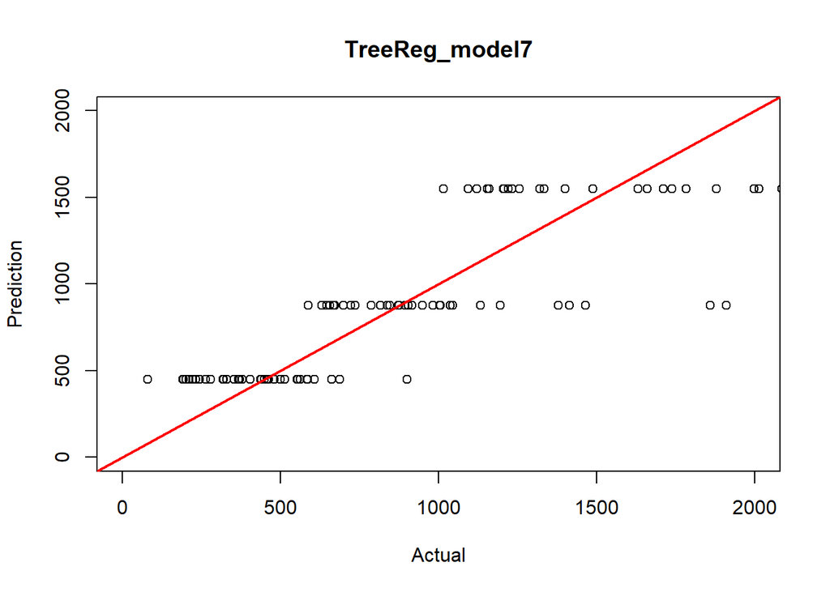

```r
pred_tree  <- predict(tree_3P, test)

## Absolute error mean, median, sd, max, min
abs_err_tree <- abs(pred_tree - test$Apps)
models_comp  <- rbind(models_comp, "TreeReg_model7" = c(rmse(test$Apps, pred_tree),
                                                 mean(abs_err_tree),
                                                 median(abs_err_tree),
                                                 sd(abs_err_tree),
                                                 IQR(abs_err_tree),
                                                 range(abs_err_tree)))

## Actual vs. Predicted
plot(test$Apps, pred_tree, main = 'TreeReg_model7',
     xlim = c(0, 2000), ylim = c(0, 2000),
     xlab = "Actual", ylab = "Prediction")
abline(a = 0, b = 1, col = "red", lwd = 2)
```

**Note:** we can see Actual vs Prediction this way, because we use tree methods.  
**Note:** Mean absolute error and RMSE are increased to **707.19** and **1361.64**, respectively. In this way we are going to use more complex trees.

### Model 4 Baggin and Random forest

Because we have seen we need some more complex models we are going to use **Baggin** and **Random forest**, however, I have already done RF ar the first in draft for getting more knowledge about feature selection. But I have mote mentioned in this Markdown.

#### Model 4-1 Bagging

```r
bagging <- randomForest(Apps ~ . , mtry = ncol(train) - 2, ntree = 500, data = train2)
bagging
```

```
##
## Call:
##  randomForest(formula = Apps ~ ., data = train2, mtry = ncol(train) -      2, ntree = 500)
##                Type of random forest: regression
##                      Number of trees: 500
## No. of variables tried at each split: 16
##
##           Mean of squared residuals: 871509.5
##                     % Var explained: 92.71
```

**Note:** it is figured that accuracy of **Baggin** is 92 percent.

#### Prediction Model 4-1 Bagging

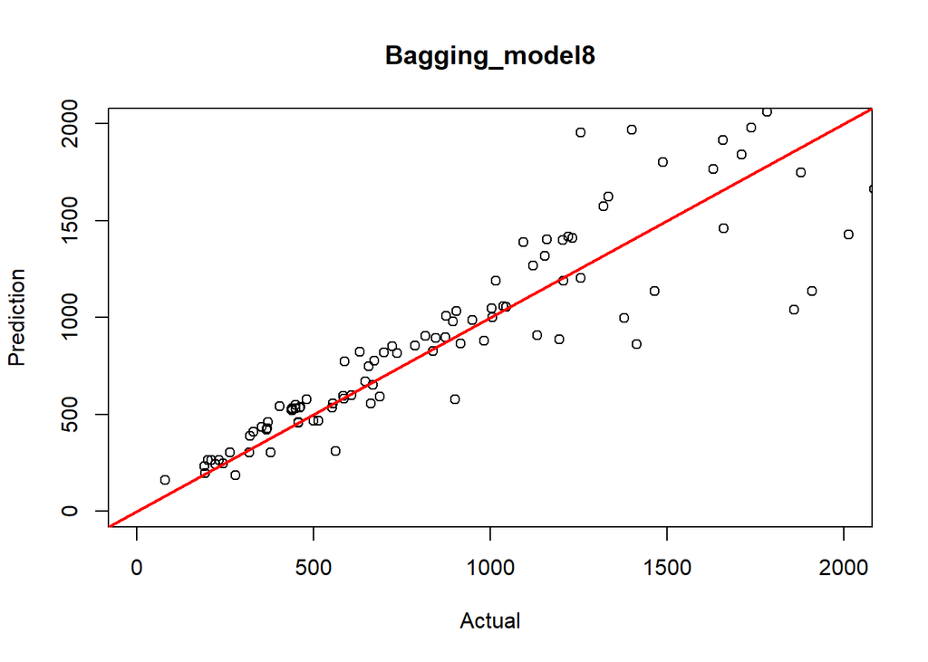

```r
## Absolute error mean, median, sd, max, min
pred_bagging  <- predict(bagging, test)
abs_err_bagging <- abs(pred_bagging - test$Apps)
models_comp <- rbind(models_comp, "Bagging_model8" = c(rmse(test$Apps, pred_bagging),
                                                 mean(abs_err_bagging),
                                                 median(abs_err_bagging),
                                                 sd(abs_err_bagging),
                                                 IQR(abs_err_bagging),
                                                 range(abs_err_bagging)))

## Actual vs. Predicted
plot(test$Apps, pred_bagging, main = 'Bagging_model8',
     xlim = c(0, 2000), ylim = c(0, 2000),
     xlab = "Actual", ylab = "Prediction")
abline(a = 0, b = 1, col = "red", lwd = 2)
```

**Note:** This plot shows us the left part of test are improved rather than previous models. Moreover, **RMSE** is **896.19** and **Mean Absolute Error** is **458.09**. So, we can say until now this is the Best model we made. So, we will take a look at **RF**.

#### Model 4-2 random Forest

```r
## mtry
#     for regression = p/3
rf_1 <- randomForest(Apps ~ . , data = train,
                     mtry = 6, ntree = 500, nodesize = 5, importance = TRUE)

rf_1
```

```
##
## Call:
##  randomForest(formula = Apps ~ ., data = train, mtry = 6, ntree = 500,      nodesize = 5, importance = TRUE)
##                Type of random forest: regression
##                      Number of trees: 500
## No. of variables tried at each split: 6
##
##           Mean of squared residuals: 2723754
##                     % Var explained: 82.71
```

**Note:** The RF has a decent accuracy. **Note:** Invisibly, the importance of the variables that is plotted in the following.In this plot we can see **Accept**, **Enroll** and **F.Undergrad** are highest importance, and Books, S.F.Ratio does not have that much importance.

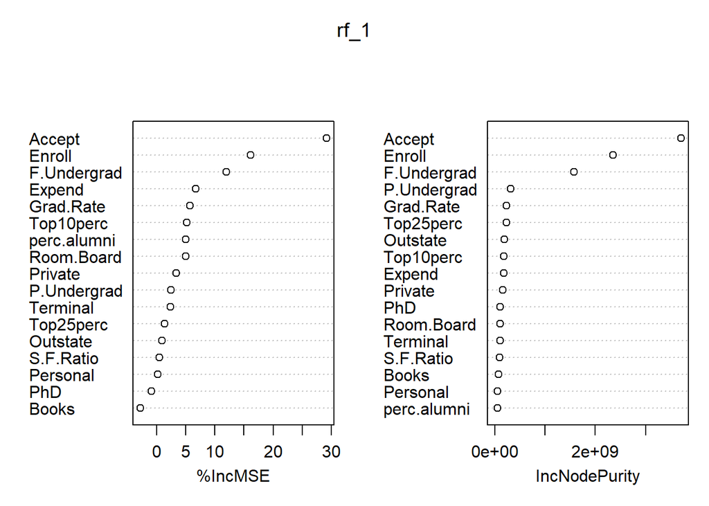

```r
varImpPlot(rf_1)
```

#### Model 4-3 random Forest with CV

In this model we are going to use cross validation to find the best value of hyperparameters.

```r
rf_cv <- rfcv(train[, - c(2)],
              train$Apps,
              cv.fold = 10,
              step = 0.75,
              mtry = function(p) max(1, floor(sqrt(p))),
              recursive = FALSE)
str(rf_cv)
```

```
## List of 3
##  $ n.var    : num [1:9] 17 13 10 7 5 4 3 2 1
##  $ error.cv : Named num [1:9] 2798802 2697466 2595474 2751957 2685144 ...
##   ..- attr(*, "names")= chr [1:9] "17" "13" "10" "7" ...
##  $ predicted:List of 9
##   ..$ 17: num [1:621] 3379 621 4812 2349 720 ...
##   ..$ 13: num [1:621] 3345 646 4763 2492 705 ...
##   ..$ 10: num [1:621] 3493 587 4459 2179 717 ...
##   ..$ 7 : num [1:621] 3671 575 4674 2214 740 ...
##   ..$ 5 : num [1:621] 4306 547 4753 2211 701 ...
##   ..$ 4 : num [1:621] 3912 535 4546 1875 669 ...
##   ..$ 3 : num [1:621] 3676 550 4131 2498 753 ...
##   ..$ 2 : num [1:621] 3833 515 3802 1645 682 ...
##   ..$ 1 : num [1:621] 5205 547 3220 1635 534 ...
```

From **feature selection** with RF:

```r
## Regression formula
reg_formula <- as.formula(Apps ~ Accept  + Enroll + F.Undergrad + Top10perc +
                            Room.Board  + Grad.Rate + Top25perc + Outstate +
                            Expend + Private + perc.alumni + Terminal + PhD +
                            P.Undergrad )

rf_2 <- randomForest(reg_formula, data = train2, mtry = 3, ntree = 500, nodesize = 5)
rf_2
```

```
##
## Call:
##  randomForest(formula = reg_formula, data = train2, mtry = 3,      ntree = 500, nodesize = 5)
##                Type of random forest: regression
##                      Number of trees: 500
## No. of variables tried at each split: 3
##
##           Mean of squared residuals: 958538.3
##                     % Var explained: 91.98
```

**Note:** Accuracy as improved around **9%**, so we can say, model is improved.

#### Prediction Model 4-3 random Forest with CV

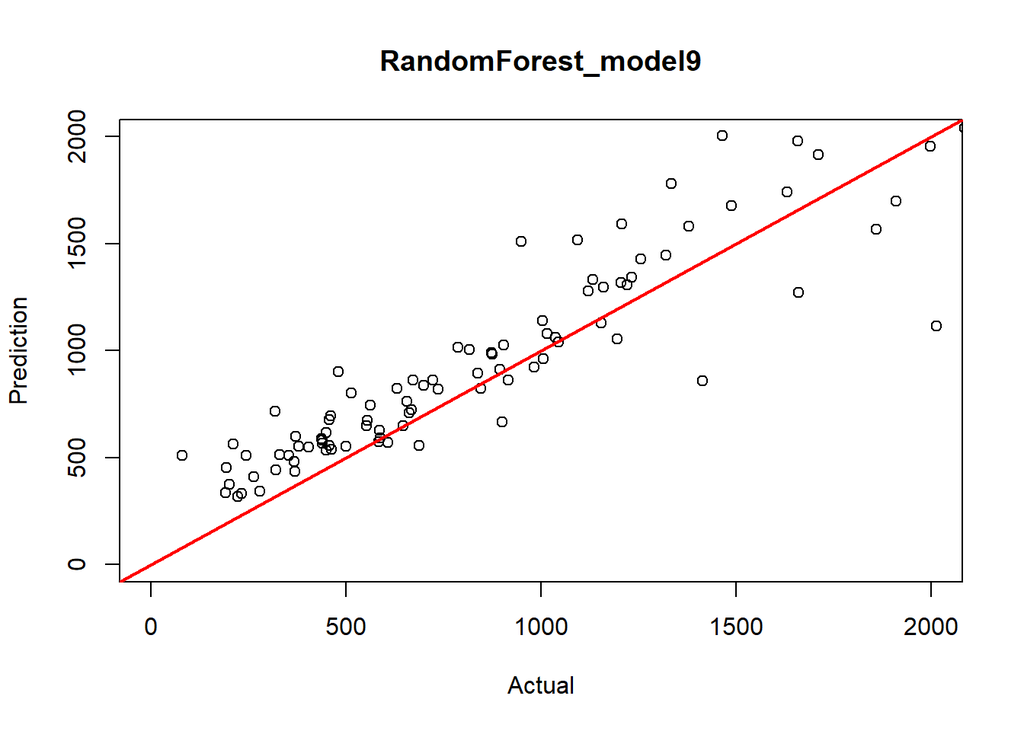

```r
pred_rf  <- predict(rf_2, test)

abs_err_rf <- abs(pred_rf - test$Apps)
models_comp <- rbind(models_comp, "RandomForest_model9" = c(rmse(test$Apps, pred_rf),
                                                      mean(abs_err_rf),
                                                     median(abs_err_rf),
                                                     sd(abs_err_rf),
                                                     IQR(abs_err_rf),
                                                     range(abs_err_rf)))

plot(test$Apps, pred_rf, main = 'RandomForest_model9',
     xlim = c(0, 2000), ylim = c(0, 2000),
     xlab = "Actual", ylab = "Prediction")
abline(a = 0, b = 1, col = "red", lwd = 2)
```

```r
knitr::kable(
  models_comp , caption = 'Comparing models.'
)
```

Comparing models.

|  | RMSE | Mean.of.AbsErrors | Median.of.AbsErrors | SD.of.AbsErrors | IQR.of.AbsErrors | Min.of.AbsErrors | Max.of.AbsErrors |
| --- | --- | --- | --- | --- | --- | --- | --- |
| LM_AllFeature_model1 | 973.2118 | 582.5972 | 314.9756 | 782.0758 | 546.9115 | 3.3152656 | 5923.688 |
| LM_Ttest_model2 | 976.4392 | 575.7099 | 303.3804 | 791.2044 | 568.8033 | 3.3776476 | 6057.296 |
| BestSubset_RAdj_model3 | 972.9671 | 580.6685 | 311.0475 | 783.2122 | 564.2475 | 1.6338568 | 5933.761 |
| BestSubset_CV_model4 | 978.1606 | 584.3787 | 316.1097 | 786.9367 | 537.1093 | 1.7441864 | 6035.741 |
| RidgeReg_model5 | 975.0719 | 584.5706 | 320.6875 | 782.9251 | 576.6574 | 0.2851734 | 5922.923 |
| LASSOReg_model6 | 973.4585 | 582.0816 | 319.3540 | 782.7709 | 559.1354 | 3.4287591 | 5930.840 |
| TreeReg_model7 | 1361.6402 | 707.1900 | 286.9812 | 1167.3394 | 513.7927 | 0.1779661 | 6612.816 |
| Bagging_model8 | 896.1997 | 458.0915 | 160.0712 | 772.7574 | 457.8332 | 1.4007667 | 5670.035 |
| RandomForest_model9 | 864.4946 | 483.0014 | 209.9968 | 719.2893 | 420.7226 | 2.5759000 | 5168.846 |

**Note:** It is obvious **Bagging** and **RF** are better performance than other linear and simple decision tree. However, **Bagging** has lower **Mean absolute error** than **RF**. But Generally, both model are good for deploying on the real condition.

```r
##load("case1_testPreproces.R")
train2$Private <- factor(train2$Private)
test$Private <- factor(test$Private)
```

### Model 5 GB Regression

we have made Tinning for Creating hyper-parameter grid, Two times hyper-parameter are trying to find. At first attempt, I just found a range and second attempt I focused on that range more. I have changed it to comment for increasing the speed.

#### Model 5-1 GB hyper-parameter

```r
# par_grid <- expand.grid(shrinkage = c(0.01, 0.15, 0.1, 0.3),  #learning rate
#                         interaction_depth = c(1,2 ,3, 5), #the maximum depth of each tree
#                         n_minobsinnode = c(5, 10, 15, 20),  #the minimum number of observations in the terminal nodes of the trees
#                         bag_fraction = c(0.5, 0.7, 0.8,0.9) #stochastic gradient :bag.fraction < 1
# )
#
#
# ## Grid search (train/validation approach)
# for(i in 1:nrow(par_grid)) {
#   set.seed(123)
#   #train model
#   gbm_tune <- gbm(formula =  Apps ~ + .,
#                   distribution = "gaussian",
#                   data = train2,
#                   n.trees = 5000,
#                   interaction.depth = par_grid$interaction_depth[i],
#                   shrinkage = par_grid$shrinkage[i],
#                   n.minobsinnode = par_grid$n_minobsinnode[i],
#                   bag.fraction = par_grid$bag_fraction[i],
#                   train.fraction = 0.8,
#                   #cv.folds = 5,
#                   n.cores = NULL, #will use all cores by default
#                   verbose = FALSE)
#   #add min training error and trees to grid
#   par_grid$optimal_trees[i] <- which.min(gbm_tune$valid.error)
#   par_grid$min_RMSE[i]      <- sqrt(min(gbm_tune$valid.error))
# }
# #
# head(par_grid)
```

#### Model 5-2 GB hyper-parameter

I try to focused on the previous ranges, more.

```r
# par_grid2 <- expand.grid(shrinkage = c(0.01, 0.15, 0.1, 0.3),  #learning rate
#                         interaction_depth = c(2,3), #the maximum depth of each tree
#                         n_minobsinnode = c(5) , #the minimum number of observations in the terminal nodes of the trees
#                         bag_fraction = c(0.6, 0.7,0.8, 0.9)
#                         )
# ## Grid search (train/validation approach)
# for(i in 1:nrow(par_grid2)) {
#   set.seed(123)
#   #train model
#   gbm_tune <- gbm(formula = Apps ~ + .,
#                   distribution = "gaussian",
#                   data = train2,
#                   n.trees = 5000,
#                   interaction.depth = par_grid2$interaction_depth[i],
#                   shrinkage = par_grid2$shrinkage[i],
#                   n.minobsinnode = par_grid2$n_minobsinnode[i],
#                   bag.fraction = par_grid2$bag_fraction[i],
#                   train.fraction = 0.8,
#                   cv.folds = 0,
#                   n.cores = NULL, #will use all cores by default
#                   verbose = FALSE)
#   #add min training error and trees to grid
#   par_grid2$optimal_trees[i] <- which.min(gbm_tune$valid.error)
#   par_grid2$min_RMSE[i]    <- sqrt(min(gbm_tune$valid.error))
# }
```

#### Model 5-3 GB final

I have found the best hyper-parameter values in draft files from above codes and I copy and paste them here.

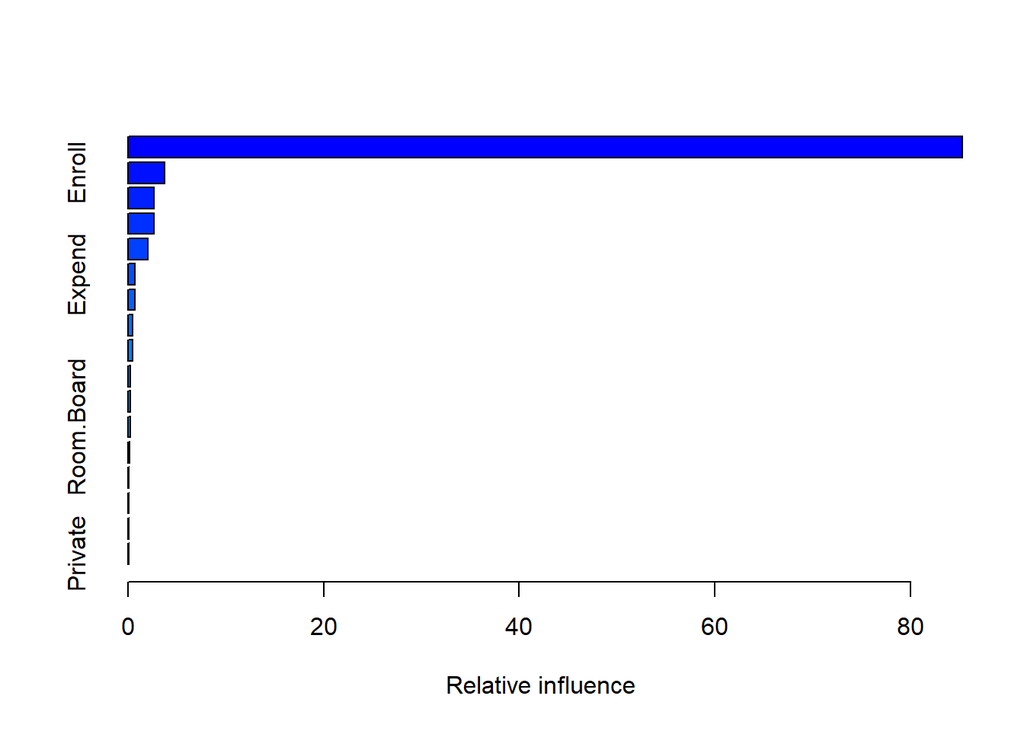

```
##                     var     rel.inf
## Accept           Accept 85.31837459
## Enroll           Enroll  3.73794585
## Top25perc     Top25perc  2.68235608
## Top10perc     Top10perc  2.63196724
## F.Undergrad F.Undergrad  2.00755537
## Expend           Expend  0.73986153
## Outstate       Outstate  0.70294799
## Personal       Personal  0.47980412
## Grad.Rate     Grad.Rate  0.46575240
## Books             Books  0.27447003
## P.Undergrad P.Undergrad  0.26497735
## Room.Board   Room.Board  0.20636463
## S.F.Ratio     S.F.Ratio  0.17707786
## PhD                 PhD  0.12468690
## perc.alumni perc.alumni  0.07571085
## Terminal       Terminal  0.06005291
## Private         Private  0.05009432
```

```r
gbmFinal <- gbm(formula = Apps  ~ . ,
             distribution = "gaussian",
             data = train2,
             n.trees = 1622,
             interaction.depth = 2,
             shrinkage =0.01,
             n.minobsinnode = 5,
             bag.fraction = 0.6,
             train.fraction = 1,
             cv.folds = 0,
             n.cores = NULL, #will use all cores by default
)

summary(gbmFinal)
```

#### Prediction Model 5-3 GB final

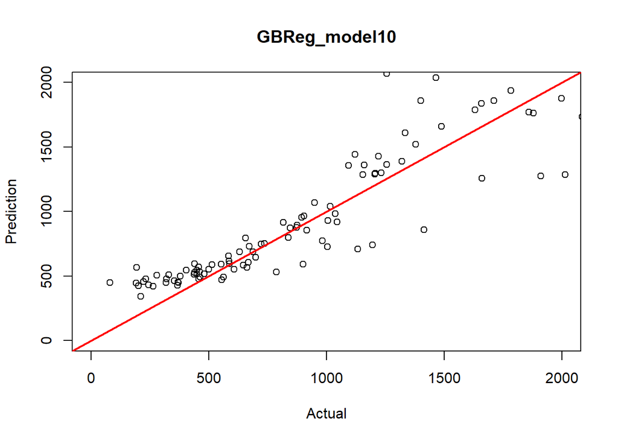

```r
pred_gbm <- predict(gbmFinal, n.trees = 1622, newdata = test)
## Absolute error mean, median, sd, max, min
abs_err_gbm <- abs(pred_gbm - test$Apps)
models_comp <- rbind(models_comp, "GBReg_model10" = c(rmse(test$Apps, pred_gbm),
                                              mean(abs_err_gbm),
                                              median(abs_err_gbm),
                                              sd(abs_err_gbm),
                                              IQR(abs_err_gbm),
                                              range(abs_err_gbm)))
## Actual vs. Predicted
plot(test$Apps, pred_gbm, main = 'GBReg_model10',
     xlim = c(0, 2000), ylim = c(0, 2000),
     xlab = "Actual", ylab = "Prediction")
abline(a = 0, b = 1, col = "red", lwd = 2)
```

### Model 5 XGB

#### Model 5-1 XGB Tuning and validation

At first I tried to Tune the hyper-parameter with this method. I turned it to comment, for increasing the speed of Knitting.

```r
# x <- model.matrix(Apps ~ . , data = train2)[, -1] #remove intercept
# y <- train2$Apps
# set.seed(1234)
# train_cases <- sample(1:nrow(train2), nrow(train2) * 0.8)
# ## Train data set
# train_xgboost <- train[train_cases,]
# dim(train_xgboost)
# ## Model Matrix
# xtrain <- model.matrix(Apps ~ . , data = train_xgboost)[, -1] #remove intercept
# ytrain <- train_xgboost$Apps
# ## Validation data set
# validation_xgboost  <- train[- train_cases,]
# dim(validation_xgboost)
# xvalidation <- model.matrix(Apps ~ . , data = validation_xgboost)[, -1] #remove intercept
# yvalidation <- validation_xgboost$Apps
#
#
# par_grid <- expand.grid(eta = c(0.01, 0.05, 0.1, 0.3),
#                         lambda = c(0, 1, 2, 5),
#                         max_depth = c(1, 3, 5, 7),
#                         subsample = c(0.65, 0.8, 1),
#                         colsample_bytree = c(0.8, 0.9, 1))
#
#
# #Grid search
# for(i in 1:nrow(par_grid)) {
#   set.seed(123)
#
#   #train model
#   xgb_tune <- xgboost(data =  xtrain,
#                       label = ytrain,
#                       eta = par_grid$eta[i],
#                       max_depth = par_grid$max_depth[i],
#                       subsample = par_grid$subsample[i],
#                       colsample_bytree = par_grid$colsample_bytree[i],
#                       nrounds = 1000,
#                       objective = "reg:squarederror",  #for regression models
#                       verbose = 0,                     #silent,
#                       early_stopping_rounds = 10       #stop if no improvement for 10 consecutive trees
#   )
#
#   #prediction on validation data set
#   pred_xgb_validation <- predict(xgb_tune, xvalidation)
#   rmse <- sqrt(mean((yvalidation - pred_xgb_validation) ^ 2))
#
#   #add validation error
#   par_grid$RMSE[i]  <- rmse
# }
#
# ## save(par_gridLog, file = "par_grid_xgboost.R")
```

So, from selected hyper-parameter I make the final XGB.

#### Model 5-2 XGB Final

```r
set.seed(123)
xgb <- xgboost(data = x,
                 label = y,
                 eta = 0.1,     #learning rate
                 max_depth = 3,  #tree depth
                 lambda = 0,
                 nround = 1000,
                 colsample_bytree = 0.9,
                 subsample = 0.65,                #percent of training data to sample for each tree
                 objective = "reg:squarederror",  #for regression models
                 verbose = 0,                      #silent
                 early_stopping_rounds = 10
)
```

#### Prediction Model 5-2 XGB Final

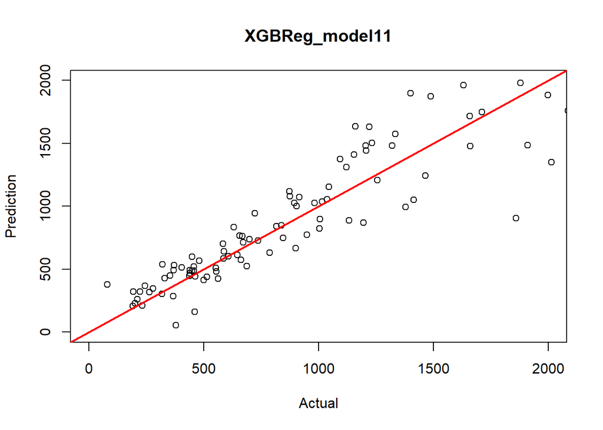

```r
x_test   <- model.matrix(Apps ~ . , data = test)[, -1]#remove intercept
pred_xgb <- predict(xgb, x_test)

## Absolute error mean, median, sd, max, min
abs_err_xgb <- abs(pred_xgb - test$Apps)
models_comp <- rbind(models_comp, "XGBReg_model11" = c(rmse(test$Apps, pred_xgb),
                                               mean(abs_err_xgb),
                                               median(abs_err_xgb),
                                               sd(abs_err_xgb),
                                               IQR(abs_err_xgb),
                                               range(abs_err_xgb)))
## Actual vs. Predicted
plot(test$Apps, pred_xgb, main = 'XGBReg_model11',
     xlim = c(0, 2000), ylim = c(0, 2000),
     xlab = "Actual", ylab = "Prediction")
abline(a = 0, b = 1, col = "red", lwd = 2)
```

# Compare the test errors and evalution of models

## 1. The proposed models are evaluated on experimental data using common indicators in machine learning.

```r
knitr::kable(
  models_comp , caption = 'Comparing models.'
)
```

Comparing models.

|  | RMSE | Mean.of.AbsErrors | Median.of.AbsErrors | SD.of.AbsErrors | IQR.of.AbsErrors | Min.of.AbsErrors | Max.of.AbsErrors |
| --- | --- | --- | --- | --- | --- | --- | --- |
| LM_AllFeature_model1 | 973.2118 | 582.5972 | 314.9756 | 782.0758 | 546.9115 | 3.3152656 | 5923.688 |
| LM_Ttest_model2 | 976.4392 | 575.7099 | 303.3804 | 791.2044 | 568.8033 | 3.3776476 | 6057.296 |
| BestSubset_RAdj_model3 | 972.9671 | 580.6685 | 311.0475 | 783.2122 | 564.2475 | 1.6338568 | 5933.761 |
| BestSubset_CV_model4 | 978.1606 | 584.3787 | 316.1097 | 786.9367 | 537.1093 | 1.7441864 | 6035.741 |
| RidgeReg_model5 | 975.0719 | 584.5706 | 320.6875 | 782.9251 | 576.6574 | 0.2851734 | 5922.923 |
| LASSOReg_model6 | 973.4585 | 582.0816 | 319.3540 | 782.7709 | 559.1354 | 3.4287591 | 5930.840 |
| TreeReg_model7 | 1361.6402 | 707.1900 | 286.9812 | 1167.3394 | 513.7927 | 0.1779661 | 6612.816 |
| Bagging_model8 | 896.1997 | 458.0915 | 160.0712 | 772.7574 | 457.8332 | 1.4007667 | 5670.035 |
| RandomForest_model9 | 864.4946 | 483.0014 | 209.9968 | 719.2893 | 420.7226 | 2.5759000 | 5168.846 |
| GBReg_model10 | 722.0997 | 427.0662 | 207.2024 | 584.1488 | 401.1416 | 1.3253190 | 3098.700 |
| XGBReg_model11 | 747.9589 | 421.6435 | 209.5561 | 619.7754 | 385.8020 | 1.6792603 | 4041.493 |

**Based on Comparing Error:** Based on Compare table above, it figures that **XGB** has the lowest **Mean Absolute Error** and **GB** has the loest **RMSE**. Therefore, we can say these two models they have good out put and high accuser with lowest possible error. However, **Bagging** and **RF** are located in the next position for having the highest accuracy and lowest error after **XGB** and **GB**.However, if we do not have access to sufficient computer power, we can use those two insted of **XGB** and **GB**.

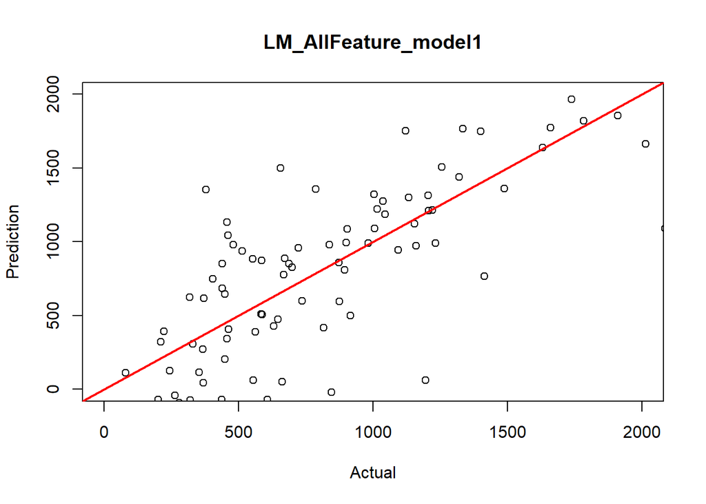

```r
plot(test$Apps, pred_mAll, main = 'LM_AllFeature_model1',
     xlim = c(0, 2000), ylim = c(0, 2000),
     xlab = "Actual", ylab = "Prediction")
abline(a = 0, b = 1, col = "red", lwd = 2)
```

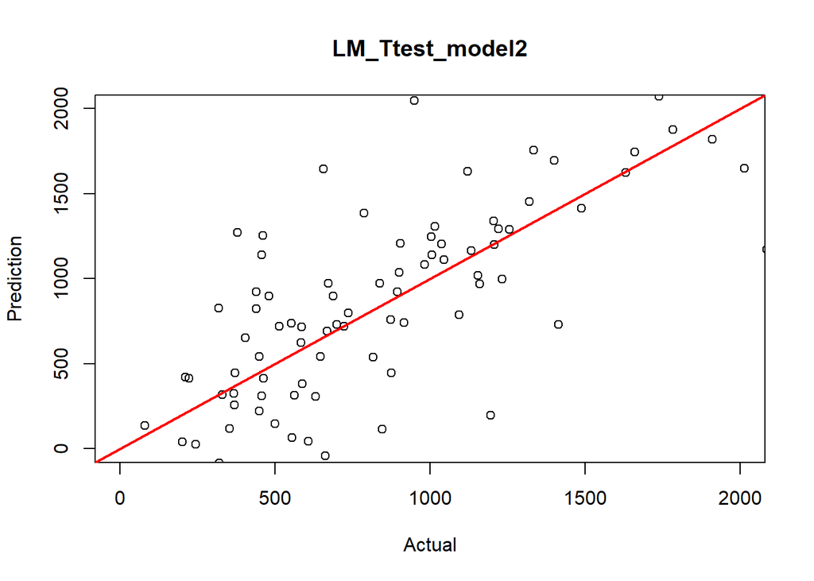

```r
plot(test$Apps, pred_mTtest, main = 'LM_Ttest_model2',
     xlim = c(0, 2000), ylim = c(0, 2000),
     xlab = "Actual", ylab = "Prediction")
abline(a = 0, b = 1, col = "red", lwd = 2)
```

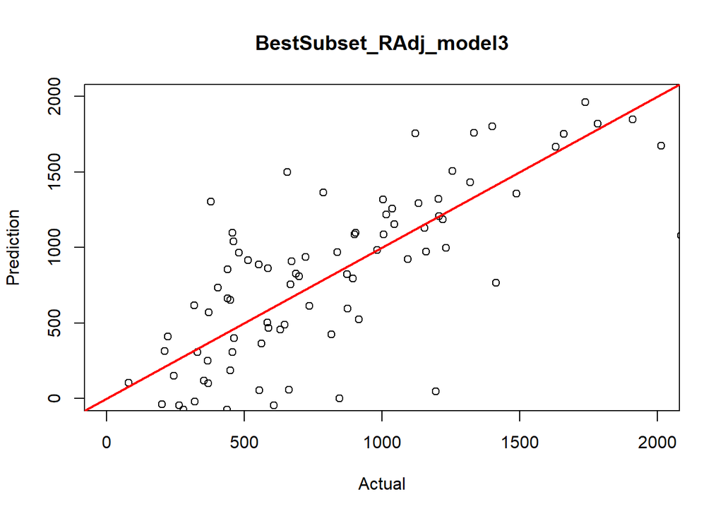

```r
plot(test$Apps, pred_bestsubAdj, main = 'BestSubset_RAdj_model3',
     xlim = c(0, 2000), ylim = c(0, 2000),
     xlab = "Actual", ylab = "Prediction")
abline(a = 0, b = 1, col = "red", lwd = 2)
```

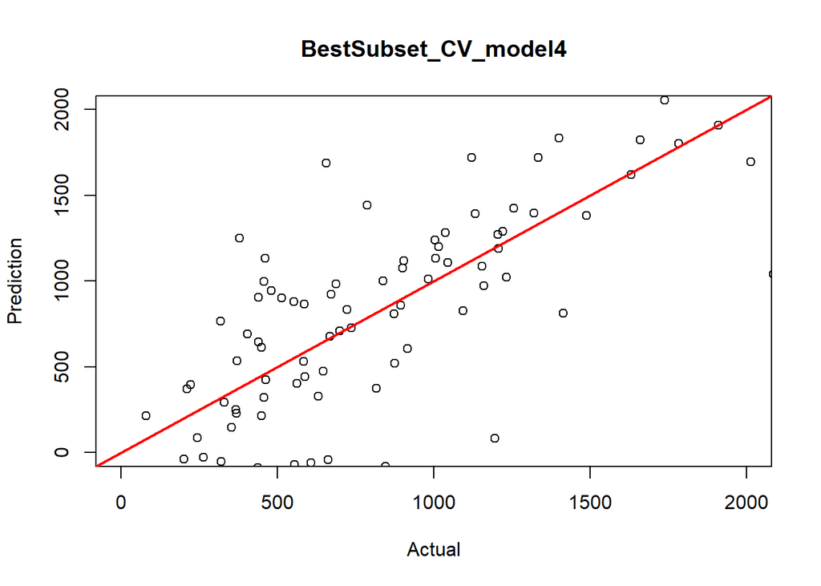

```r
plot(test$Apps, pred_bestsub_cv, main = 'BestSubset_CV_model4',
     xlim = c(0, 2000), ylim = c(0, 2000),
     xlab = "Actual", ylab = "Prediction")
abline(a = 0, b = 1, col = "red", lwd = 2)
```

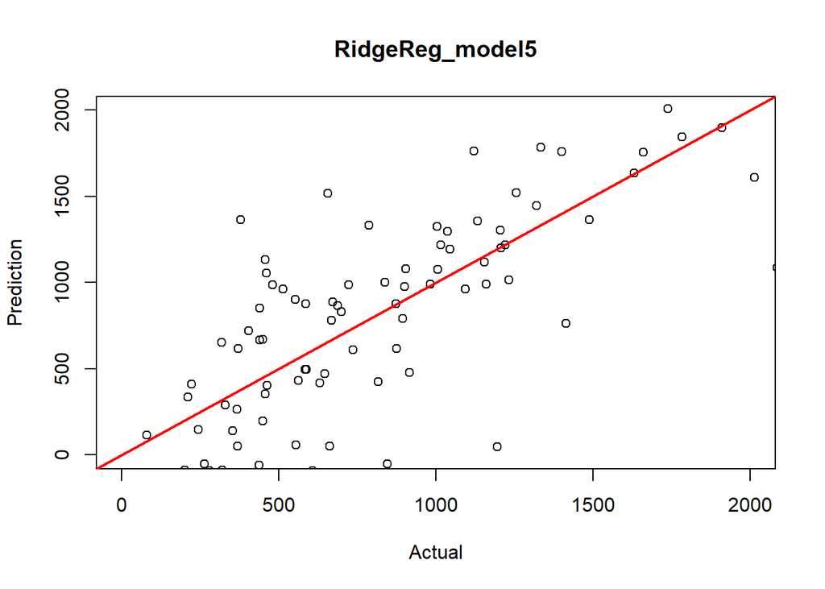

```r
plot(test$Apps, pred_ridgereg, main = 'RidgeReg_model5',
     xlim = c(0, 2000), ylim = c(0, 2000),
     xlab = "Actual", ylab = "Prediction")

abline(a = 0, b = 1, col = "red", lwd = 2)
```

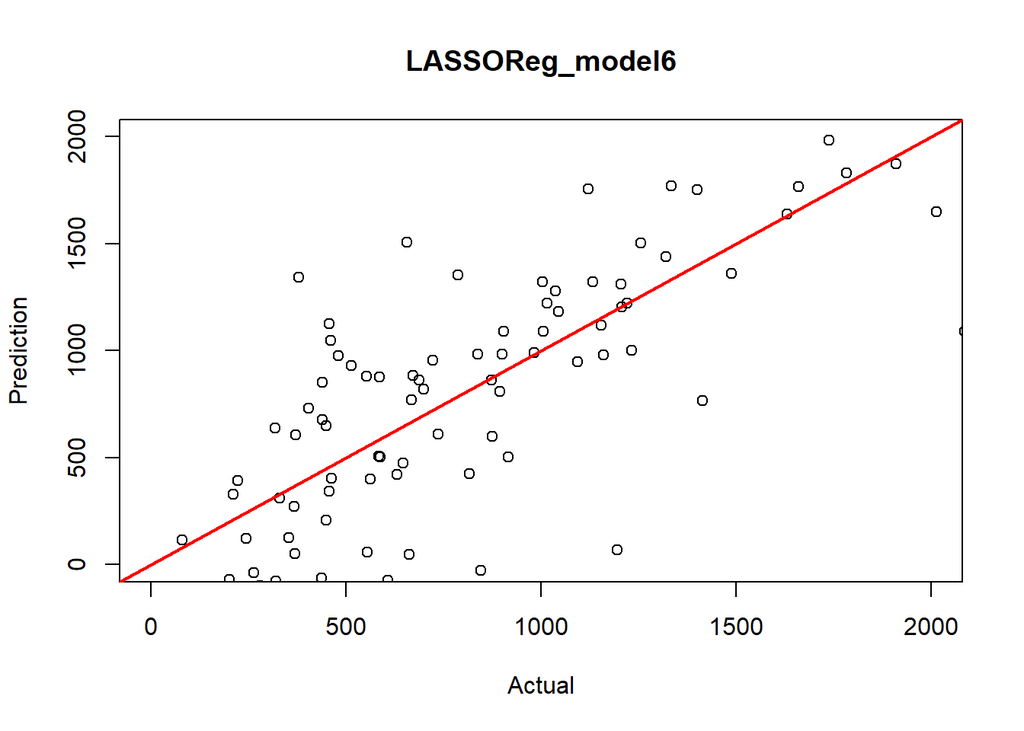

```r
plot(test$Apps, pred_lassoreg, main = 'LASSOReg_model6',
     xlim = c(0, 2000), ylim = c(0, 2000),
     xlab = "Actual", ylab = "Prediction")
abline(a = 0, b = 1, col = "red", lwd = 2)
```

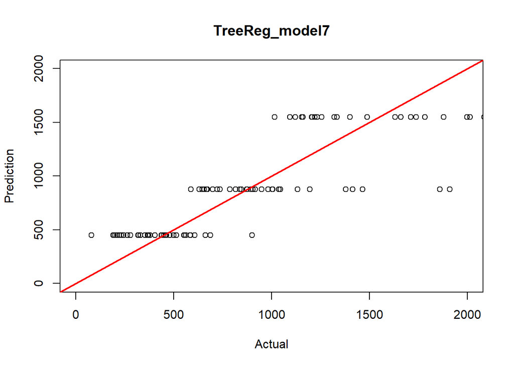

```r
plot(test$Apps, pred_tree, main = 'TreeReg_model7',
     xlim = c(0, 2000), ylim = c(0, 2000),
     xlab = "Actual", ylab = "Prediction")
abline(a = 0, b = 1, col = "red", lwd = 2)
```

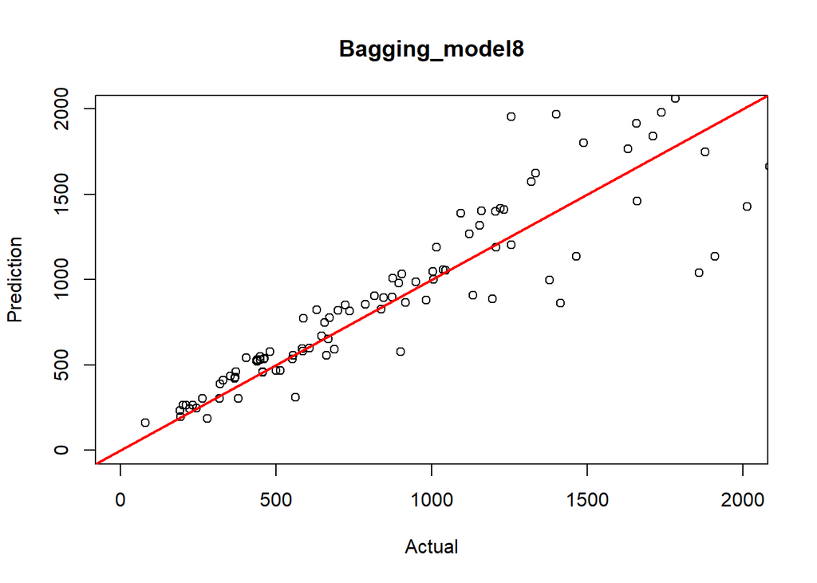

```r
plot(test$Apps, pred_bagging, main = 'Bagging_model8',
     xlim = c(0, 2000), ylim = c(0, 2000),
     xlab = "Actual", ylab = "Prediction")
abline(a = 0, b = 1, col = "red", lwd = 2)
```

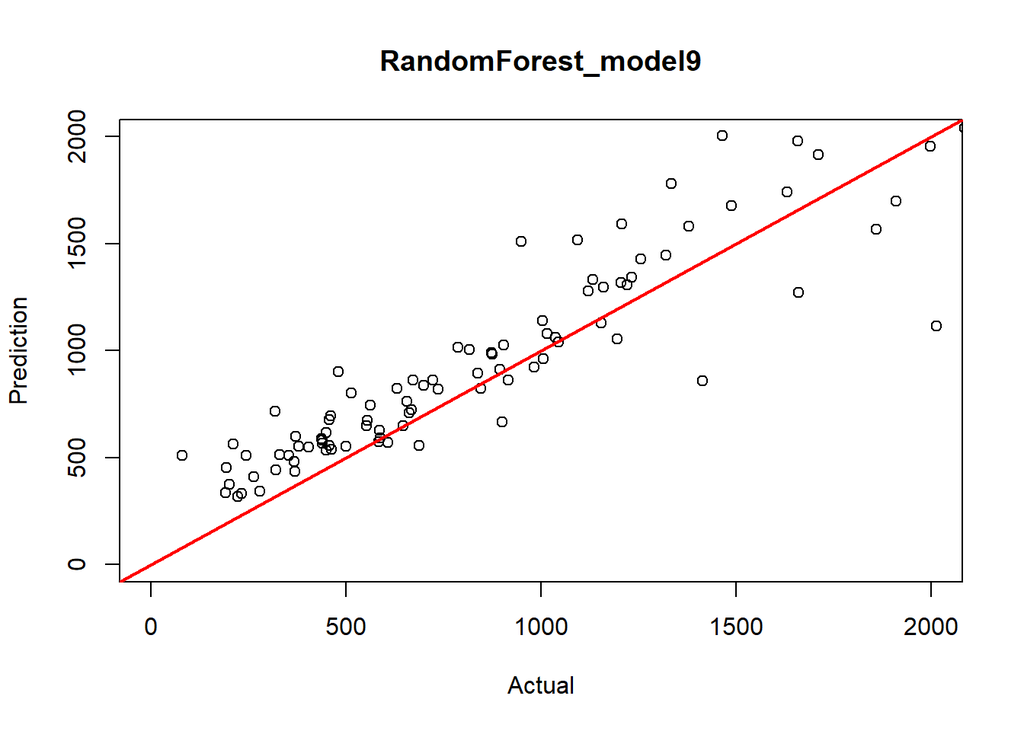

```r
plot(test$Apps, pred_rf, main = 'RandomForest_model9',
     xlim = c(0, 2000), ylim = c(0, 2000),
     xlab = "Actual", ylab = "Prediction")
abline(a = 0, b = 1, col = "red", lwd = 2)
```

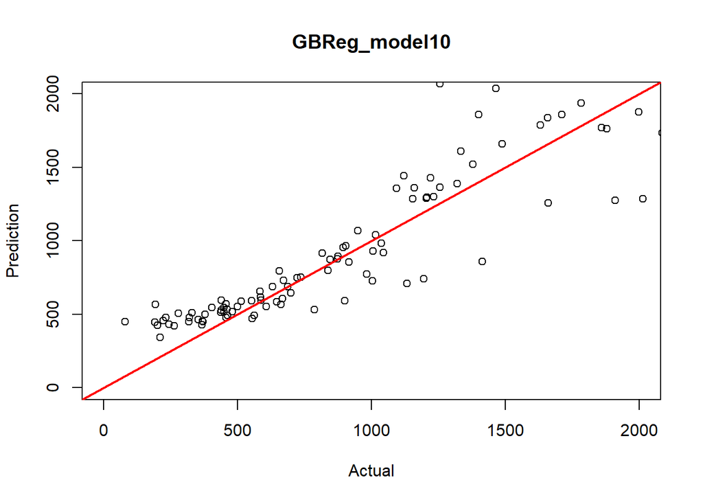

```r
plot(test$Apps, pred_gbm, main = 'GBReg_model10',
     xlim = c(0, 2000), ylim = c(0, 2000),
     xlab = "Actual", ylab = "Prediction")
abline(a = 0, b = 1, col = "red", lwd = 2)
```

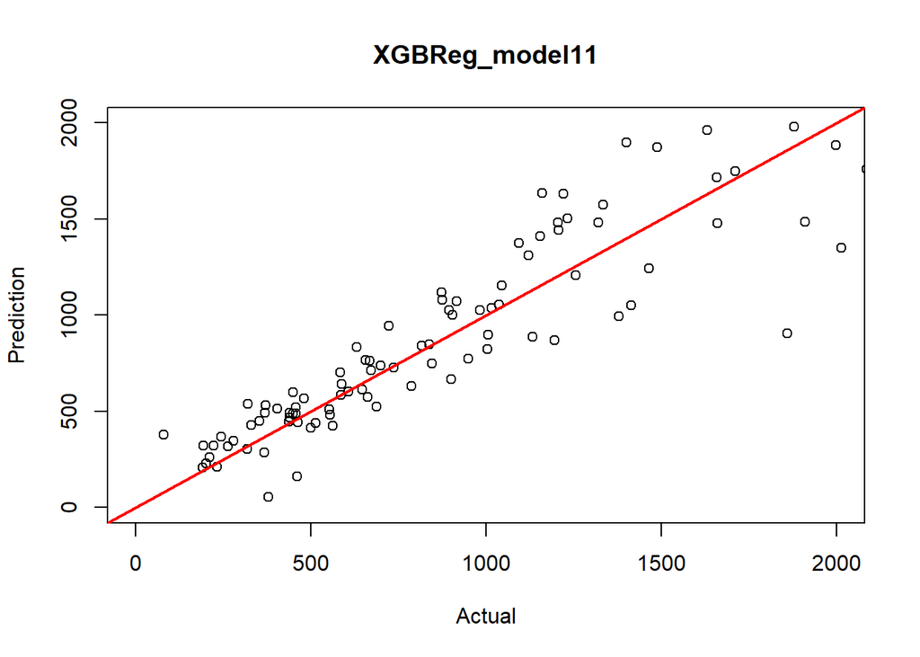

```r
plot(test$Apps, pred_xgb, main = 'XGBReg_model11',
     xlim = c(0, 2000), ylim = c(0, 2000),
     xlab = "Actual", ylab = "Prediction")
abline(a = 0, b = 1, col = "red", lwd = 2)
```

## 2. What suggestions do you have for testing the results in a real environment?

We can use survey methods, to collect some new data from recent years, because these data were collected in 1995, and after 27 years, we can see the error of these models on the new data. However, we can compare it to some other old data, which is so much closer to 1995 than right now. For instance, I think this model will have high accuracy in **schools around 1996-2000** in the US.

# Deploy model

Now if you want to develop such an algorithm on an industrial scale, think about what challenges you will face and what solutions you have for it.

## 1. Examine the challenges of algorithm development

Maybe another important feature has not been reported in dataset. Also, some other feature do not play an important role in this study.

## 2. What solutions do you have to solve them?

Comparing this data with new dataset. And we can see this model would work or not.

## 3. What requirements do you need to provide those solutions?

having access to an API for taking new data and comparing this data with this dataset.

# Conclusion

## 1. What you have leared from this study?

Using Machine learning methods to study the Number of Application for college in US.  
In this study, I have found out how I can find a decent algorithm with changing hyper parameter and different models  
The most important thing I have learned, it was data understanding and knowing the feature, because using the difference algoritm and code, would a repeated task and without knowing data and data understating, data would not tell us anythings. So, I think understating the data concept is most important thing I have learned.  
However, story telling is located in the high priority too.

## 2. What challenges did you face? How did you solve them?

data visualization and showing them in the best way has some challenges which I have found out them on the Internet.  
Another challenge I have face, was data understanding and the concept and definition of some this data, which I have search them in the Internet and I have tried to find the concept of the feature. Because we are not familiar to US curriculum.

```r
knitr::knit_exit()
```